# Semantic Image Segmentation - Part 2

## U-Net

U-net is built on top of the fully convolutional network from above. It was built for medical purposes to find tumors in the lungs or brain. It also consists of an encoder that downsamples the input image to a feature map and the decoder that samples the feature map to the size of the input image using learned deconvolution layers.

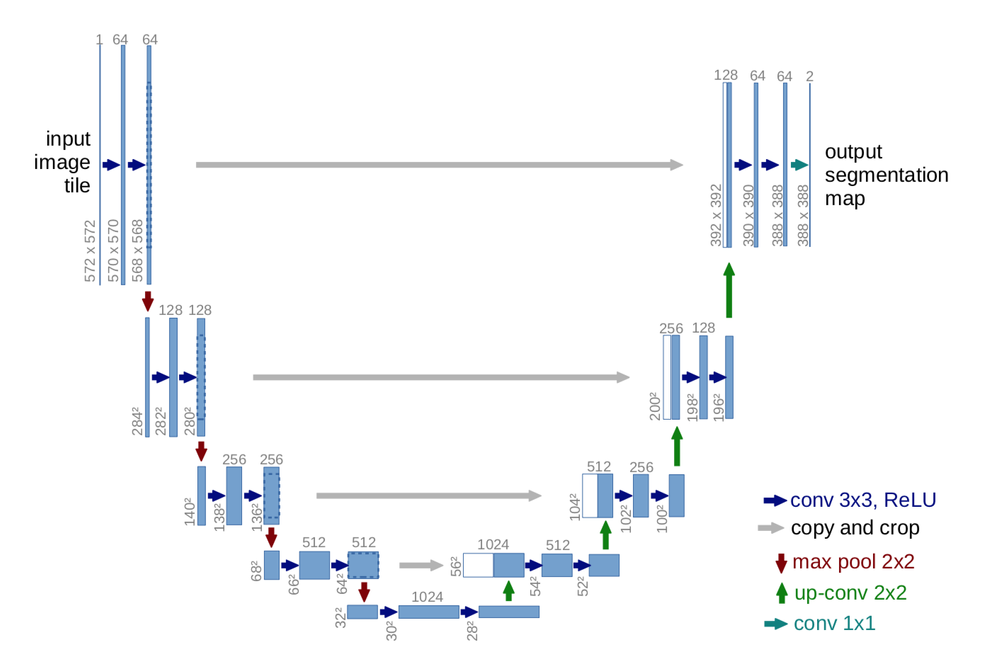

The main contribution of the U-Net architecture is the shortcut connections. We saw above in FCN that since we downsample an image as part of the encoder, we lose a lot of information that cannot be easily recovered at the encoder part. FCN tries to solve this by getting information from the pooling layers before the final feature layer.

It can be split into an encoder-decoder path or an expansion-contraction path equivalently.

Encoder (left side): Consists of repeatedly applying two 3x3 convolutions. Each conv is followed by a ReLU and batch normalization. Then, a 2x2 max pooling operation is applied to reduce the spatial dimensions. Again, at each downsampling step, we double the number of feature channels while halving the spatial dimensions.

Decoder path (right side): Each step in the expansion path consists of an upsampling of the feature map followed by a 2x2 transposition convolution, which halves the number of feature channels. We also have a concatenation with the corresponding feature map from the contracting path and usually a 3x3 convolution (each followed by a ReLU). In the final layer, a 1x1 convolution is used to map the channels to the desired number of classes.

In this U-Net example, we will use the following dataset: Mapping floodwater from radar images:

https://www.drivendata.org/competitions/81/detect-flood-water/page/385/

The dataset consists of SAR images, with Sentinel 1 VV and VH bands, and their respective masks representing flooded areas.

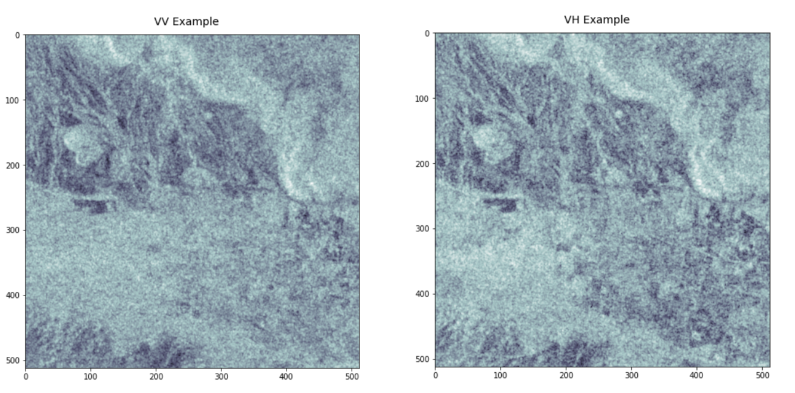

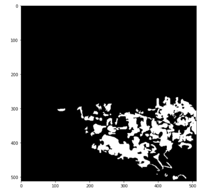

Let's then import the necessary libraries, functions and data:

```python
!pip install rasterio
```

```
     ━━━━━━━━━━━━━━━━━━━━━━━━━━━━━━━━━━━━━━━━ 21.3/21.3 MB 47.5 MB/s eta 0:00:00
```

```python
from google.colab import drive
drive.mount('/content/drive')
```

```python
import rasterio
import pandas as pd
import glob
import os
import cv2
import numpy as np
import matplotlib.pyplot as plt
```

```python
path_csv = 'drive/My Drive/Datasets/Flood_challenge/flood-training-metadata.csv'
```

```python
metadata = pd.read_csv(path_csv)
```

```python
metadata.head()
```

|  | image_id | chip_id | flood_id | polarization | location | scene_start |
| --- | --- | --- | --- | --- | --- | --- |
| 0 | awc00_vh | awc00 | awc | vh | Bolivia | 2018-02-15 |
| 1 | awc00_vv | awc00 | awc | vv | Bolivia | 2018-02-15 |
| 2 | awc01_vh | awc01 | awc | vh | Bolivia | 2018-02-15 |
| 3 | awc01_vv | awc01 | awc | vv | Bolivia | 2018-02-15 |
| 4 | awc02_vh | awc02 | awc | vh | Bolivia | 2018-02-15 |

```python
len(pd.unique(metadata.chip_id))
```

```
542
```

```python
path_images = 'drive/My Drive/Datasets/Flood_challenge/train_features'
path_labels = 'drive/My Drive/Datasets/Flood_challenge/train_labels'
```

We can use Lee Filter to smooth and remove noise from the S1 bands:

```python
from scipy.ndimage.filters import uniform_filter
from scipy.ndimage.measurements import variance
```

```python
def lee_filter(img, size):
    img_mean = uniform_filter(img, (size, size))
    img_sqr_mean = uniform_filter(img**2, (size, size))
    img_variance = img_sqr_mean - img_mean**2
    overall_variance = variance(img)
    img_weights = img_variance**2 / (img_variance**2 + overall_variance**2)
    img_output = img_mean + img_weights * (img - img_mean)
    return img_output
```

Let's import input data and masks:

```python
X = []
for pref in pd.unique(metadata.chip_id):
  import_vv = os.path.join(path_images,pref + '_vv.tif')
  import_vh = os.path.join(path_images,pref + '_vh.tif')
  with rasterio.open(import_vv) as src:
    vv = src.read()
  vv = vv.transpose([1,2,0])
  vv = lee_filter(vv[:,:,0],5)
  with rasterio.open(import_vh) as src:
    vh = src.read()
  vh = vh.transpose([1,2,0])
  vh = lee_filter(vh[:,:,0],5)
  im = np.dstack((vv,vh))
  print(im.shape)
  X.append(im)
X = np.array(X)
print(X.shape)
```

[output not shown]

[output cut: 488 more lines]

```
(512, 512, 2)
(512, 512, 2)
(512, 512, 2)
(512, 512, 2)
(512, 512, 2)
(512, 512, 2)
(512, 512, 2)
(512, 512, 2)
(512, 512, 2)
(512, 512, 2)
(512, 512, 2)
(512, 512, 2)
(512, 512, 2)
(512, 512, 2)
(542, 512, 512, 2)
```

```python
Y = []
for pref in pd.unique(metadata.chip_id):
  import_lb = os.path.join(path_labels,pref + '.tif')
  with rasterio.open(import_lb) as src:
    lb = src.read()
  lb = lb.transpose([1,2,0])
  print(lb.shape)
  Y.append(lb)
Y = np.array(Y)
print(Y.shape)
```

[output not shown]

[output cut: 488 more lines]

```
(512, 512, 1)
(512, 512, 1)
(512, 512, 1)
(512, 512, 1)
(512, 512, 1)
(512, 512, 1)
(512, 512, 1)
(512, 512, 1)
(512, 512, 1)
(512, 512, 1)
(512, 512, 1)
(512, 512, 1)
(512, 512, 1)
(512, 512, 1)
(542, 512, 512, 1)
```

After converting to numpy array, let's normalize the data to the range 0 to 1:

```python
X_int = cv2.normalize(X, None, alpha=0, beta=1, norm_type=cv2.NORM_MINMAX)
```

```python
Y_int = np.where(Y==255,0,Y)
```

We can then plot the two bands and the mask:

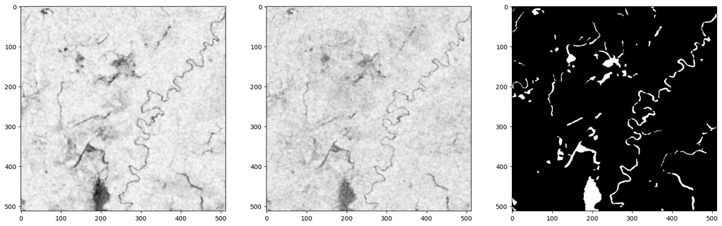

```python
plt.figure(figsize=(20,8))
plt.subplot(1,3,1),
plt.imshow(X_int[10,:,:,0], cmap='Greys_r')
plt.subplot(1,3,2),
plt.imshow(X_int[10,:,:,1], cmap='Greys_r')
plt.subplot(1,3,3),
plt.imshow(Y_int[10,:,:,0], cmap='Greys_r')
```

Let's split the data into training and testing:

```python
from sklearn.model_selection import train_test_split
from sklearn.metrics import accuracy_score
```

```python
x_train, x_test, y_train, y_test = train_test_split(X_int, Y_int, test_size=0.25, random_state=10)
```

```python
y_train = y_train.astype('float')
y_test = y_test.astype('float')
```

```python
del X,Y, X_int, Y_int
```

```python
from keras.models import Model
from keras.layers import Input, Conv2D, MaxPooling2D, UpSampling2D, concatenate, Concatenate, add, Conv2DTranspose, BatchNormalization, Dropout, Activation, Add, AveragePooling2D, Lambda, SeparableConv2D, GlobalAveragePooling2D, DepthwiseConv2D, ZeroPadding2D, LeakyReLU
#from tensorflow.keras.optimizers import Adam
from keras.optimizers import Adam
from keras.activations import relu
from tensorflow.keras.preprocessing.image import ImageDataGenerator
from keras.losses import binary_crossentropy
from keras import backend as K
import tensorflow as tf
from keras.models import load_model
from keras.models import model_from_json
from tensorflow.keras.losses import Dice
```

In this example, we will use data augmentation to generate more training samples:

```python
img_datagen = ImageDataGenerator(
    rotation_range=90,
    vertical_flip = True,
    horizontal_flip=True,
    width_shift_range = 0.2,
    height_shift_range = 0.2,
    zoom_range = 0.2)

mask_datagen = ImageDataGenerator(
    rotation_range=90,
    vertical_flip = True,
    horizontal_flip=True,
    width_shift_range = 0.2,
    height_shift_range = 0.2,
    zoom_range = 0.2)
```

```python
img_datagen.fit(x_train, augment=True,seed=1200)
mask_datagen.fit(y_train, augment=True,seed=1200)
```

```python
train_generator=img_datagen.flow(x_train,y_train,batch_size=8,seed=1200)
```

```python
steps_per_epoch = len(x_train)//8
validation_steps = len(x_test)//8
```

So let's implement U-Net:

```python
upconv = True
droprate = 0.5
inputs = Input(shape=x_train.shape[1:])
conv1 = Conv2D(32, (3, 3), activation='elu', kernel_initializer='he_normal', padding='same')(inputs)
conv1 = Conv2D(32, (3, 3), activation='elu', kernel_initializer='he_normal', padding='same')(conv1)
pool1 = MaxPooling2D(pool_size=(2, 2))(conv1)


pool1 = BatchNormalization()(pool1)
conv2 = Conv2D(64, (3, 3), activation='elu', kernel_initializer='he_normal', padding='same')(pool1)
conv2 = Conv2D(64, (3, 3), activation='elu', kernel_initializer='he_normal', padding='same')(conv2)
pool2 = MaxPooling2D(pool_size=(2, 2))(conv2)
pool2 = Dropout(droprate)(pool2)

pool2 = BatchNormalization()(pool2)
conv3 = Conv2D(128, (3, 3), activation='elu', kernel_initializer='he_normal', padding='same')(pool2)
conv3 = Conv2D(128, (3, 3), activation='elu', kernel_initializer='he_normal', padding='same')(conv3)
pool3 = MaxPooling2D(pool_size=(2, 2))(conv3)
pool3 = Dropout(droprate)(pool3)

pool3 = BatchNormalization()(pool3)
conv4 = Conv2D(256, (3, 3), activation='elu', kernel_initializer='he_normal', padding='same')(pool3)
conv4 = Conv2D(256, (3, 3), activation='elu', kernel_initializer='he_normal', padding='same')(conv4)
pool4 = MaxPooling2D(pool_size=(2, 2))(conv4)
pool4 = Dropout(droprate)(pool4)

pool4 = BatchNormalization()(pool4)
conv5 = Conv2D(512, (3, 3), activation='elu', kernel_initializer='he_normal', padding='same')(pool4)
conv5 = Conv2D(512, (3, 3), activation='elu', kernel_initializer='he_normal', padding='same')(conv5)
pool5 = MaxPooling2D(pool_size=(2, 2))(conv5)
pool5 = Dropout(droprate)(pool5)

pool5 = BatchNormalization()(pool5)
conv6 = Conv2D(1024, (3, 3), activation='elu', kernel_initializer='he_normal', padding='same')(pool5)
conv6 = Conv2D(1024, (3, 3), activation='elu', kernel_initializer='he_normal', padding='same')(conv6)
conv6 = Dropout(droprate)(conv6)

if upconv:
  up6 = concatenate([Conv2DTranspose(512, (2, 2), strides=(2, 2), padding='same')(conv6), conv5])
else:
  up6 = concatenate([UpSampling2D(size=(2, 2))(conv6), conv5])
up6 = BatchNormalization()(up6)
conv7 = Conv2D(512, (3, 3), activation='elu', kernel_initializer='he_normal', padding='same')(up6)
conv7 = Conv2D(512, (3, 3), activation='elu', kernel_initializer='he_normal', padding='same')(conv7)
conv7 = Dropout(droprate)(conv7)

if upconv:
  up7 = concatenate([Conv2DTranspose(256, (2, 2), strides=(2, 2), padding='same')(conv7), conv4])
else:
  up7 = concatenate([UpSampling2D(size=(2, 2))(conv7), conv4])
up7 = BatchNormalization()(up7)
conv8 = Conv2D(256, (3, 3), activation='elu', kernel_initializer='he_normal', padding='same')(up7)
conv8 = Conv2D(256, (3, 3), activation='elu', kernel_initializer='he_normal', padding='same')(conv8)
conv8 = Dropout(droprate)(conv8)

if upconv:
  up8 = concatenate([Conv2DTranspose(128, (2, 2), strides=(2, 2), padding='same')(conv8), conv3])
else:
  up8 = concatenate([UpSampling2D(size=(2, 2))(conv8), conv3])
up8 = BatchNormalization()(up8)
conv9 = Conv2D(128, (3, 3), activation='elu', kernel_initializer='he_normal', padding='same')(up8)
conv9 = Conv2D(128, (3, 3), activation='elu', kernel_initializer='he_normal', padding='same')(conv9)
conv9 = Dropout(droprate)(conv9)

if upconv:
  up9 = concatenate([Conv2DTranspose(64, (2, 2), strides=(2, 2), padding='same')(conv9), conv2])
else:
  up9 = concatenate([UpSampling2D(size=(2, 2))(conv9), conv2])
up9 = BatchNormalization()(up9)
conv10 = Conv2D(64, (3, 3), activation='elu', kernel_initializer='he_normal', padding='same')(up9)
conv10 = Conv2D(64, (3, 3), activation='elu', kernel_initializer='he_normal', padding='same')(conv10)
conv10 = Dropout(droprate)(conv10)

if upconv:
  up10 = concatenate([Conv2DTranspose(32, (2, 2), strides=(2, 2), padding='same')(conv10), conv1])
else:
  up10 = concatenate([UpSampling2D(size=(2, 2))(conv10), conv1])
up10 = BatchNormalization()(up10)
conv11 = Conv2D(32, (3, 3), activation='elu', kernel_initializer='he_normal', padding='same')(up10)
conv11 = Conv2D(32, (3, 3), activation='elu', kernel_initializer='he_normal', padding='same')(conv11)


conv12 = Conv2D(1, (1, 1), activation='sigmoid')(conv11)
model = Model(inputs=inputs, outputs=conv12)

model.compile(optimizer=Adam(learning_rate = 1e-5), loss = Dice, metrics=['accuracy'])
model.summary()
```

```
Model: "functional"
```

```
┏━━━━━━━━━━━━━━━━━━━━━━━━━━━┳━━━━━━━━━━━━━━━━━━━━━━━━┳━━━━━━━━━━━━━━━━┳━━━━━━━━━━━━━━━━━━━━━━━━┓
┃ Layer (type)              ┃ Output Shape           ┃        Param # ┃ Connected to           ┃
┡━━━━━━━━━━━━━━━━━━━━━━━━━━━╇━━━━━━━━━━━━━━━━━━━━━━━━╇━━━━━━━━━━━━━━━━╇━━━━━━━━━━━━━━━━━━━━━━━━┩
│ input_layer (InputLayer)  │ (None, 512, 512, 2)    │              0 │ -                      │
├───────────────────────────┼────────────────────────┼────────────────┼────────────────────────┤
│ conv2d (Conv2D)           │ (None, 512, 512, 32)   │            608 │ input_layer[0][0]      │
├───────────────────────────┼────────────────────────┼────────────────┼────────────────────────┤
│ conv2d_1 (Conv2D)         │ (None, 512, 512, 32)   │          9,248 │ conv2d[0][0]           │
├───────────────────────────┼────────────────────────┼────────────────┼────────────────────────┤
│ max_pooling2d             │ (None, 256, 256, 32)   │              0 │ conv2d_1[0][0]         │
│ (MaxPooling2D)            │                        │                │                        │
├───────────────────────────┼────────────────────────┼────────────────┼────────────────────────┤
│ batch_normalization       │ (None, 256, 256, 32)   │            128 │ max_pooling2d[0][0]    │
│ (BatchNormalization)      │                        │                │                        │
├───────────────────────────┼────────────────────────┼────────────────┼────────────────────────┤
│ conv2d_2 (Conv2D)         │ (None, 256, 256, 64)   │         18,496 │ batch_normalization[0… │
├───────────────────────────┼────────────────────────┼────────────────┼────────────────────────┤
│ conv2d_3 (Conv2D)         │ (None, 256, 256, 64)   │         36,928 │ conv2d_2[0][0]         │
├───────────────────────────┼────────────────────────┼────────────────┼────────────────────────┤
│ max_pooling2d_1           │ (None, 128, 128, 64)   │              0 │ conv2d_3[0][0]         │
│ (MaxPooling2D)            │                        │                │                        │
├───────────────────────────┼────────────────────────┼────────────────┼────────────────────────┤
│ dropout (Dropout)         │ (None, 128, 128, 64)   │              0 │ max_pooling2d_1[0][0]  │
├───────────────────────────┼────────────────────────┼────────────────┼────────────────────────┤
│ batch_normalization_1     │ (None, 128, 128, 64)   │            256 │ dropout[0][0]          │
│ (BatchNormalization)      │                        │                │                        │
├───────────────────────────┼────────────────────────┼────────────────┼────────────────────────┤
│ conv2d_4 (Conv2D)         │ (None, 128, 128, 128)  │         73,856 │ batch_normalization_1… │
├───────────────────────────┼────────────────────────┼────────────────┼────────────────────────┤
│ conv2d_5 (Conv2D)         │ (None, 128, 128, 128)  │        147,584 │ conv2d_4[0][0]         │
├───────────────────────────┼────────────────────────┼────────────────┼────────────────────────┤
│ max_pooling2d_2           │ (None, 64, 64, 128)    │              0 │ conv2d_5[0][0]         │
│ (MaxPooling2D)            │                        │                │                        │
├───────────────────────────┼────────────────────────┼────────────────┼────────────────────────┤
│ dropout_1 (Dropout)       │ (None, 64, 64, 128)    │              0 │ max_pooling2d_2[0][0]  │
├───────────────────────────┼────────────────────────┼────────────────┼────────────────────────┤
│ batch_normalization_2     │ (None, 64, 64, 128)    │            512 │ dropout_1[0][0]        │
│ (BatchNormalization)      │                        │                │                        │
├───────────────────────────┼────────────────────────┼────────────────┼────────────────────────┤
│ conv2d_6 (Conv2D)         │ (None, 64, 64, 256)    │        295,168 │ batch_normalization_2… │
```

[output cut: 89 more lines]

```
│ conv2d_transpose_4        │ (None, 512, 512, 32)   │          8,224 │ dropout_8[0][0]        │
│ (Conv2DTranspose)         │                        │                │                        │
├───────────────────────────┼────────────────────────┼────────────────┼────────────────────────┤
│ concatenate_4             │ (None, 512, 512, 64)   │              0 │ conv2d_transpose_4[0]… │
│ (Concatenate)             │                        │                │ conv2d_1[0][0]         │
├───────────────────────────┼────────────────────────┼────────────────┼────────────────────────┤
│ batch_normalization_9     │ (None, 512, 512, 64)   │            256 │ concatenate_4[0][0]    │
│ (BatchNormalization)      │                        │                │                        │
├───────────────────────────┼────────────────────────┼────────────────┼────────────────────────┤
│ conv2d_20 (Conv2D)        │ (None, 512, 512, 32)   │         18,464 │ batch_normalization_9… │
├───────────────────────────┼────────────────────────┼────────────────┼────────────────────────┤
│ conv2d_21 (Conv2D)        │ (None, 512, 512, 32)   │          9,248 │ conv2d_20[0][0]        │
├───────────────────────────┼────────────────────────┼────────────────┼────────────────────────┤
│ conv2d_22 (Conv2D)        │ (None, 512, 512, 1)    │             33 │ conv2d_21[0][0]        │
└───────────────────────────┴────────────────────────┴────────────────┴────────────────────────┘
```

```
 Total params: 31,106,113 (118.66 MB)
```

```
 Trainable params: 31,100,161 (118.64 MB)
```

```
 Non-trainable params: 5,952 (23.25 KB)
```

```python
history = model.fit(train_generator,steps_per_epoch=steps_per_epoch, validation_steps=validation_steps,
                              epochs=100, validation_data=(x_test,y_test))
```

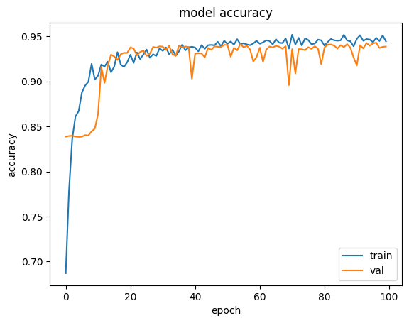

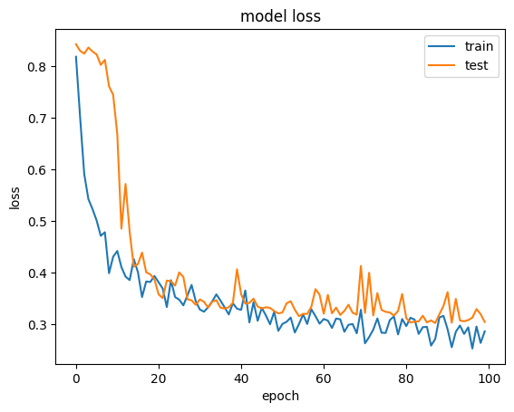

```python
plt.plot(history.history['accuracy'])
plt.plot(history.history['val_accuracy'])
plt.title('model accuracy')
plt.ylabel('accuracy')
plt.xlabel('epoch')
plt.legend(['train', 'val'], loc='lower right')
plt.show()

plt.plot(history.history['loss'])
plt.plot(history.history['val_loss'])
plt.title('model loss')
plt.ylabel('loss')
plt.xlabel('epoch')
plt.legend(['train', 'test'], loc='upper right')
plt.show()
```

```python
predict = model.predict(x_test)
```

```python
pred = np.round(predict)
```

```python
accuracy = accuracy_score(y_test.flatten(),pred.flatten())
print(accuracy)
```

```
0.9385725189657772
```

Finally, let's plot an example of the predicted result compared to the original mask:

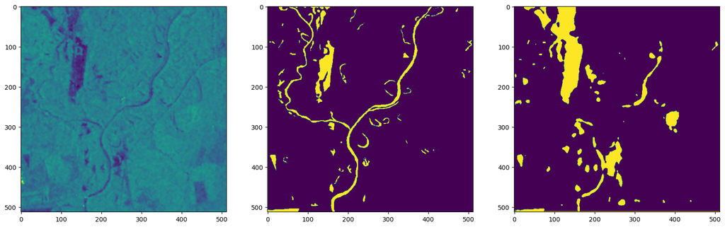

```python
i = 2
plt.figure(figsize=(20,8))
plt.subplot(1,3,1),
plt.imshow(x_test[i,:,:,0])
plt.subplot(1,3,2),
plt.imshow(y_test[i,:,:])
plt.subplot(1,3,3),
plt.imshow(pred[i,:,:,0])
```

```python
save_path = '/content/Results_img'
if not os.path.isdir(save_path):
  os.mkdir(save_path)
```

```python
for i in range(len(predict)):
  im = np.round(predict[i])
  full_im = im * 255
  full_im = full_im.astype('uint8')
  full_save_path = os.path.join(save_path,'Img_'+ str(i) + '.png')
  print(full_save_path)
  cv2.imwrite(full_save_path, full_im)
```

[output not shown]

[output cut: 81 more lines]

```
/content/Results_img/Img_121.png
/content/Results_img/Img_122.png
/content/Results_img/Img_123.png
/content/Results_img/Img_124.png
/content/Results_img/Img_125.png
/content/Results_img/Img_126.png
/content/Results_img/Img_127.png
/content/Results_img/Img_128.png
/content/Results_img/Img_129.png
/content/Results_img/Img_130.png
/content/Results_img/Img_131.png
/content/Results_img/Img_132.png
/content/Results_img/Img_133.png
/content/Results_img/Img_134.png
/content/Results_img/Img_135.png
```

### PSPNet

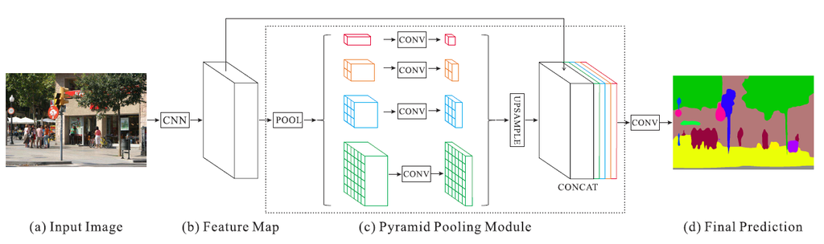

a) Input Image

Input image of any shape usually with dimensions greater than (256, 256) is fed to the network.

b) Feature Map

It takes the input image and constructs feature maps for the image. Feature maps are extracted by feeding the image using transfer learning or zero-area network with dilated convolutions. Since large size kernels extract more useful information than small size kernel but the computation cost is higher, dilated convolutions gather large size area information with small size kernel for higher dilation rates to keep the dimensions same as the input image. Generally, residual blocks with dilations are used to construct the feature maps.No.of feature maps N is a hyperparameter and needs to be tuned for good result.

c) Pyramid Pooling Module

The output of Pyramid Pooling Module is a concatenation of base feature maps from b and upsampled average pooled feature maps from c.

d) Final Prediction

The 2*N feature maps are fed to convolution layer and final prediction of classes is generated as output layer is constructed, say different channels for different objects or single channel.

PSPNet can be implemented using the following codes:

```python
def conv_block(input_tensor, filters, strides, d_rates):
    x = Conv2D(filters[0], kernel_size=1, kernel_initializer='he_uniform', dilation_rate=d_rates[0])(input_tensor)
    x = BatchNormalization()(x)
    x = Activation('relu')(x)

    x = Conv2D(filters[1], kernel_size=3, strides=strides, kernel_initializer='he_uniform', padding='same', dilation_rate=d_rates[1])(x)
    x = BatchNormalization()(x)
    x = Activation('relu')(x)

    x = Conv2D(filters[2], kernel_size=1, kernel_initializer='he_uniform', dilation_rate=d_rates[2])(x)
    x = BatchNormalization()(x)

    shortcut = Conv2D(filters[2], kernel_size=1, kernel_initializer='he_uniform', strides=strides)(input_tensor)
    shortcut = BatchNormalization()(shortcut)

    x = add([x, shortcut])
    x = Activation('relu')(x)

    return x


def identity_block(input_tensor, filters, d_rates):
    x = Conv2D(filters[0], kernel_size=1, kernel_initializer='he_uniform', dilation_rate=d_rates[0])(input_tensor)
    x = BatchNormalization()(x)
    x = Activation('relu')(x)

    x = Conv2D(filters[1], kernel_size=3, kernel_initializer='he_uniform', padding='same', dilation_rate=d_rates[1])(x)
    x = BatchNormalization()(x)
    x = Activation('relu')(x)

    x = Conv2D(filters[2], kernel_size=1, kernel_initializer='he_uniform', dilation_rate=d_rates[2])(x)
    x = BatchNormalization()(x)

    x = add([x, input_tensor])
    x = Activation('relu')(x)

    return x


def pyramid_pooling_block(input_tensor, bin_sizes):
    concat_list = [input_tensor]
    h = input_tensor.shape[1].value
    w = input_tensor.shape[2].value

    for bin_size in bin_sizes:
        x = AveragePooling2D(pool_size=(h//bin_size, w//bin_size), strides=(h//bin_size, w//bin_size))(input_tensor)
        x = Conv2D(512, kernel_size=1, kernel_initializer='he_uniform')(x)
        x = Lambda(lambda x: tf.image.resize_images(x, (h, w)))(x)

        concat_list.append(x)

    return concatenate(concat_list)
```

```python
droprate = 0.5
inputs = Input((640, 640, 14))
conv_1 = Conv2D(32, (3, 3), strides=(1, 1), kernel_initializer='he_uniform', padding='same')(inputs)
conv_1 = BatchNormalization()(conv_1)
conv_1 = Activation("relu")(conv_1)

conv_2 = Conv2D(64, (3, 3), strides=(1, 1), kernel_initializer='he_uniform', padding='same')(conv_1)
conv_2 = BatchNormalization()(conv_2)
conv_2 = Activation("relu")(conv_2)

conv_3 = Conv2D(128, (3, 3), strides=(1, 1), kernel_initializer='he_uniform', padding='same')(conv_2)
conv_3 = BatchNormalization()(conv_3)
conv_3 = Activation("relu")(conv_3)

pool_1 = MaxPooling2D((2, 2), strides=(2, 2),)(conv_3)

conv_block1 = conv_block(pool_1, filters=[64, 64, 128], strides=(1, 1), d_rates=[1, 1, 1])
identity_block1 = identity_block(conv_block1, filters=[64, 64, 128], d_rates=[1, 1, 1])
identity_block2 = identity_block(identity_block1, filters=[64, 64, 128], d_rates=[1, 1, 1])

conv_block2 = conv_block(identity_block2, filters=[128, 128, 256], strides=(2, 2), d_rates=[1, 1, 1])
identity_block3 = identity_block(conv_block2, filters=[128, 128, 256], d_rates=[1, 1, 1])
identity_block4 = identity_block(identity_block3, filters=[128, 128, 256], d_rates=[1, 1, 1])
identity_block5 = identity_block(identity_block4, filters=[128, 128, 256], d_rates=[1, 1, 1])

conv_block3 = conv_block(identity_block5, filters=[256, 256, 512], strides=(2, 2), d_rates=[1, 1, 1])
identity_block6 = identity_block(conv_block3, filters=[256, 256, 512], d_rates=[1, 2, 1])
identity_block7 = identity_block(identity_block6, filters=[256, 256, 512], d_rates=[1, 2, 1])
identity_block8 = identity_block(identity_block7, filters=[256, 256, 512], d_rates=[1, 2, 1])
identity_block9 = identity_block(identity_block8, filters=[256, 256, 512], d_rates=[1, 2, 1])
identity_block10 = identity_block(identity_block9, filters=[256, 256, 512], d_rates=[1, 2, 1])

conv_block4 = conv_block(identity_block10, filters=[512, 512, 1024], strides=(1, 1), d_rates=[1, 4, 1])
identity_block11 = identity_block(conv_block4, filters=[512, 512, 1024], d_rates=[1, 4, 1])
identity_block12 = identity_block(identity_block11, filters=[512, 512, 1024], d_rates=[1, 4, 1])

pyramid_pooling_block1 = pyramid_pooling_block(identity_block12, [1, 2, 4, 8])

conv_4 = Conv2D(512,  (3, 3), kernel_initializer='he_uniform', padding='same')(pyramid_pooling_block1)
conv_4 = BatchNormalization()(conv_4)
conv_4 = Activation('relu')(conv_4)

conv_5 = Conv2D(1, (1, 1), kernel_initializer='he_uniform', padding='same')(conv_4)
conv_5 = Conv2DTranspose(1, (16, 16), strides=(8, 8), kernel_initializer='he_uniform', padding='same')(conv_5)
outputs = Activation('softmax')(conv_5)
model = Model(inputs=inputs, outputs=outputs)
model.compile(optimizer=Adam(learning_rate = 1e-5), loss = Dice, metrics=['accuracy'])
model.summary()
```

```
Model: "model_7"
__________________________________________________________________________________________________
Layer (type)                    Output Shape         Param #     Connected to
==================================================================================================
input_7 (InputLayer)            (None, 640, 640, 14) 0
__________________________________________________________________________________________________
conv2d_367 (Conv2D)             (None, 640, 640, 32) 4064        input_7[0][0]
__________________________________________________________________________________________________
batch_normalization_337 (BatchN (None, 640, 640, 32) 128         conv2d_367[0][0]
__________________________________________________________________________________________________
activation_319 (Activation)     (None, 640, 640, 32) 0           batch_normalization_337[0][0]
__________________________________________________________________________________________________
conv2d_368 (Conv2D)             (None, 640, 640, 64) 18496       activation_319[0][0]
__________________________________________________________________________________________________
batch_normalization_338 (BatchN (None, 640, 640, 64) 256         conv2d_368[0][0]
__________________________________________________________________________________________________
activation_320 (Activation)     (None, 640, 640, 64) 0           batch_normalization_338[0][0]
__________________________________________________________________________________________________
conv2d_369 (Conv2D)             (None, 640, 640, 128 73856       activation_320[0][0]
__________________________________________________________________________________________________
batch_normalization_339 (BatchN (None, 640, 640, 128 512         conv2d_369[0][0]
__________________________________________________________________________________________________
activation_321 (Activation)     (None, 640, 640, 128 0           batch_normalization_339[0][0]
__________________________________________________________________________________________________
max_pooling2d_7 (MaxPooling2D)  (None, 320, 320, 128 0           activation_321[0][0]
__________________________________________________________________________________________________
conv2d_370 (Conv2D)             (None, 320, 320, 64) 8256        max_pooling2d_7[0][0]
__________________________________________________________________________________________________
batch_normalization_340 (BatchN (None, 320, 320, 64) 256         conv2d_370[0][0]
__________________________________________________________________________________________________
activation_322 (Activation)     (None, 320, 320, 64) 0           batch_normalization_340[0][0]
__________________________________________________________________________________________________
conv2d_371 (Conv2D)             (None, 320, 320, 64) 36928       activation_322[0][0]
__________________________________________________________________________________________________
batch_normalization_341 (BatchN (None, 320, 320, 64) 256         conv2d_371[0][0]
__________________________________________________________________________________________________
activation_323 (Activation)     (None, 320, 320, 64) 0           batch_normalization_341[0][0]
__________________________________________________________________________________________________
conv2d_372 (Conv2D)             (None, 320, 320, 128 8320        activation_323[0][0]
__________________________________________________________________________________________________
```

[output cut: 369 more lines]

```
__________________________________________________________________________________________________
batch_normalization_392 (BatchN (None, 80, 80, 512)  2048        conv2d_426[0][0]
__________________________________________________________________________________________________
activation_370 (Activation)     (None, 80, 80, 512)  0           batch_normalization_392[0][0]
__________________________________________________________________________________________________
conv2d_427 (Conv2D)             (None, 80, 80, 1)    513         activation_370[0][0]
__________________________________________________________________________________________________
conv2d_transpose_7 (Conv2DTrans (None, 640, 640, 1)  257         conv2d_427[0][0]
__________________________________________________________________________________________________
activation_371 (Activation)     (None, 640, 640, 1)  0           conv2d_transpose_7[0][0]
==================================================================================================
Total params: 33,148,322
Trainable params: 33,112,802
Non-trainable params: 35,520
__________________________________________________________________________________________________
```